# Project

tejeshwar

4/21/2020

```r
library(rvest)
library(dplyr)
library(tidyverse)
library(zoo)
library(tidyr)
library(reshape)
library(boot)
library(splines)
```

#### 1) Compare covid19 data from united states with Italy and Spain and also predict the number of cases and deaths based on data from Italy and Spain

*a)The link https://github.com/nytimes/covid-19-data/blob/master/us-states.csv contains a breakdown of US cases and deaths of COVID-19 by state*

I have used an ongoing repository of data (GitHub) on coronavirus cases and deaths in the U.S, which is maintained by New York Times. In the repository, we have data on cumulative coronavirus cases and deaths can be found in three files, one for each of these geographic levels: U.S., states, and counties. I have scraped the states level of data from the GitHub since it offers more detail than country level of data. This was little bit straightforward since we have a csv file in the repository.

```
## [1] "First six rows of usa_data and usa_state_date"
```

```
##         date cases deaths daily.cases daily.deaths
## 1 2020-01-21     1      0           0            0
## 2 2020-01-22     1      0           0            0
## 3 2020-01-23     1      0           0            0
## 4 2020-01-24     2      0           1            0
## 5 2020-01-25     3      0           1            0
## 6 2020-01-26     5      0           2            0
```

```
##         date      state cases deaths
## 1 2020-01-21 Washington     1      0
## 2 2020-01-22 Washington     1      0
## 3 2020-01-23 Washington     1      0
## 4 2020-01-24   Illinois     1      0
## 5 2020-01-24 Washington     1      0
## 6 2020-01-25 California     1      0
```

```
## [1] "Top 5 states based on total number of cases"
```

```
## # A tibble: 5 x 3
##   state           cases deaths
##   <chr>           <int>  <int>
## 1 New York      7633815 393681
## 2 New Jersey    2650820 127023
## 3 Massachusetts 1210807  54858
## 4 California    1082131  37878
## 5 Illinois      1011635  40761
```

```
## [1] "Top 5 states based on total number of deaths"
```

```
## # A tibble: 5 x 3
##   state           cases deaths
##   <chr>           <int>  <int>
## 1 New York      7633815 393681
## 2 New Jersey    2650820 127023
## 3 Michigan       985786  72405
## 4 Massachusetts 1210807  54858
## 5 Illinois      1011635  40761
```

```
## # A tibble: 6 x 6
## # Groups:   state [6]
##   date       state          cases deaths daily.cases daily.deaths
##   <date>     <chr>          <int>  <int>       <dbl>        <dbl>
## 1 2020-05-03 Virgin Islands    66      4           0            0
## 2 2020-05-03 Virginia       18671    660         940           44
## 3 2020-05-03 Washington     15580    840         327            7
## 4 2020-05-03 West Virginia   1195     50          11            0
## 5 2020-05-03 Wisconsin       7964    339         304            5
## 6 2020-05-03 Wyoming          435      7           6            0
```

```
## # A tibble: 5 x 6
## # Groups:   state [1]
##   date       state     cases deaths daily.cases daily.deaths
##   <date>     <chr>     <int>  <int>       <dbl>        <dbl>
## 1 2020-04-04 New York 114996   3568       12126          633
## 2 2020-04-15 New York 213779  11586       11571          752
## 3 2020-04-10 New York 170512   7844       10575          777
## 4 2020-04-25 New York 282174  16599       10553          437
## 5 2020-04-09 New York 159937   7067       10536          799
```

```
## # A tibble: 5 x 6
## # Groups:   state [1]
##   date       state     cases deaths daily.cases daily.deaths
##   <date>     <chr>     <int>  <int>       <dbl>        <dbl>
## 1 2020-04-07 New York 140081   5563        9392          805
## 2 2020-04-09 New York 159937   7067       10536          799
## 3 2020-04-11 New York 180458   8627        9946          783
## 4 2020-04-14 New York 202208  10834        7177          778
## 5 2020-04-10 New York 170512   7844       10575          777
```

```
## [1] "All the scenarios are from New York state, so lets look at top 5 cases from different states"
```

```
## # A tibble: 5 x 2
## # Groups:   state [5]
##   state         daily.cases
##   <chr>               <dbl>
## 1 New York            12126
## 2 Massachusetts        4946
## 3 New Jersey           4305
## 4 Illinois             3137
## 5 Louisiana            2726
```

```
## # A tibble: 5 x 2
## # Groups:   state [5]
##   state         daily.deaths
##   <chr>                <dbl>
## 1 New York               805
## 2 New Jersey             458
## 3 Pennsylvania           300
## 4 Massachusetts          252
## 5 Michigan               232
```

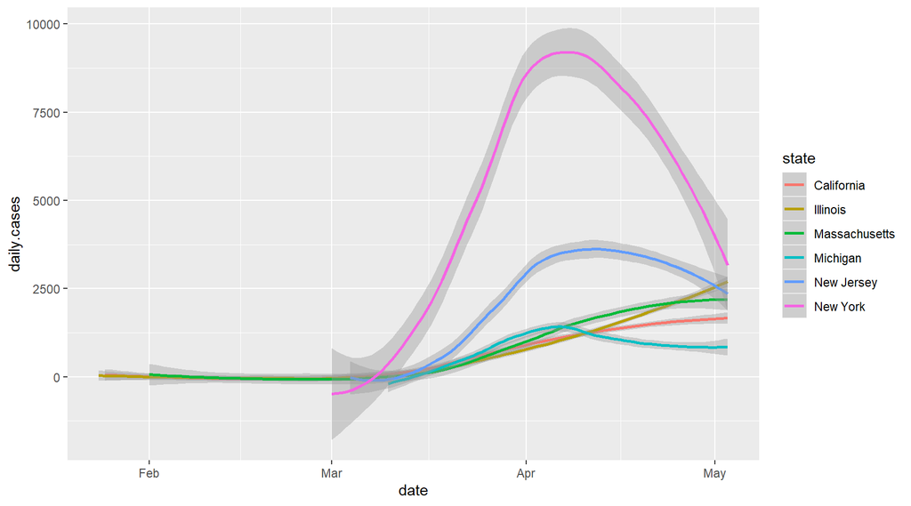

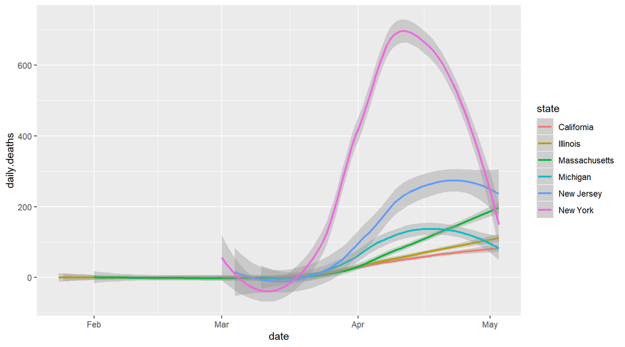

*b)The link https://en.wikipedia.org/wiki/2020_coronavirus_pandemic_in_Italy contains a breakdown of Italy cases and deaths of COVID-19 & The link https://en.wikipedia.org/wiki/2020_coronavirus_pandemic_in_Spain contains a breakdown of Spain cases and deaths*

```
## [1] "Highest number of daily cases in italy and spain are 6557 and 8195 respectively"
```

```
## [1] "Highest number of daily deaths in italy and spain are 919 and 961 respectively"
```

*c) Comparing the covid19 data of US, Spain and Italy.*

Let us look at the trend of covid19 data of US, Spain and Italy.

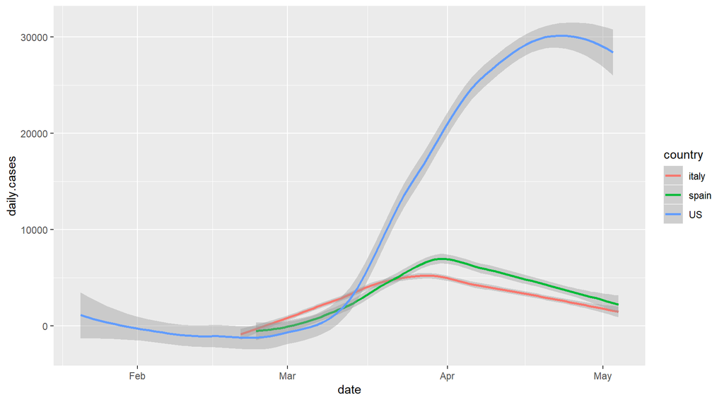

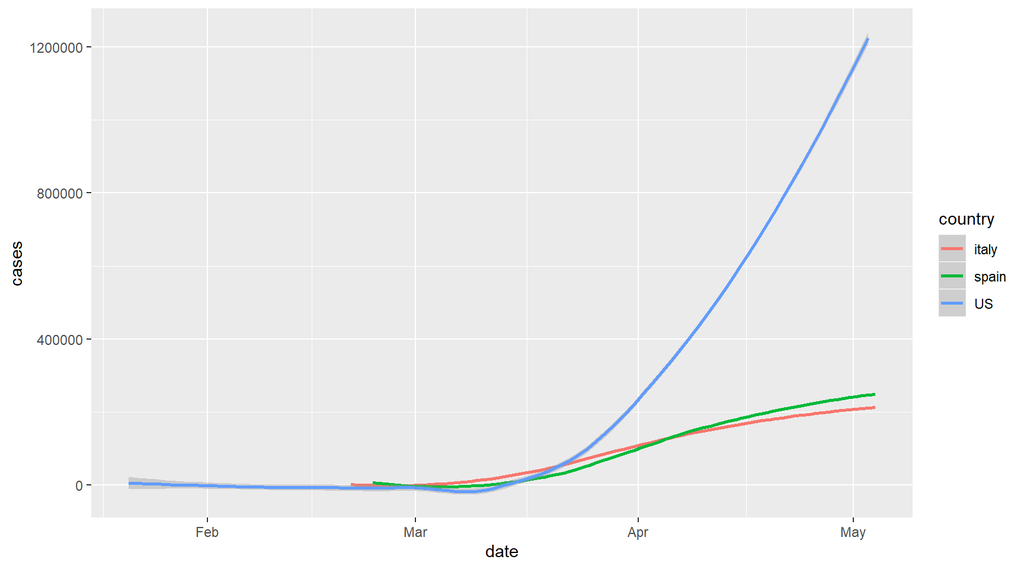

Initially when I proposed to compare italy, spain covid19 data to US, they numbers where similar but since then spain and italy had reached peak and their trend is now downwards. Whereas the US numbers still keep rising and looks like it reached peak recently.

But New York and New Jersey numbers are similar to ltaly and spain. Lets plot their graph and check it.

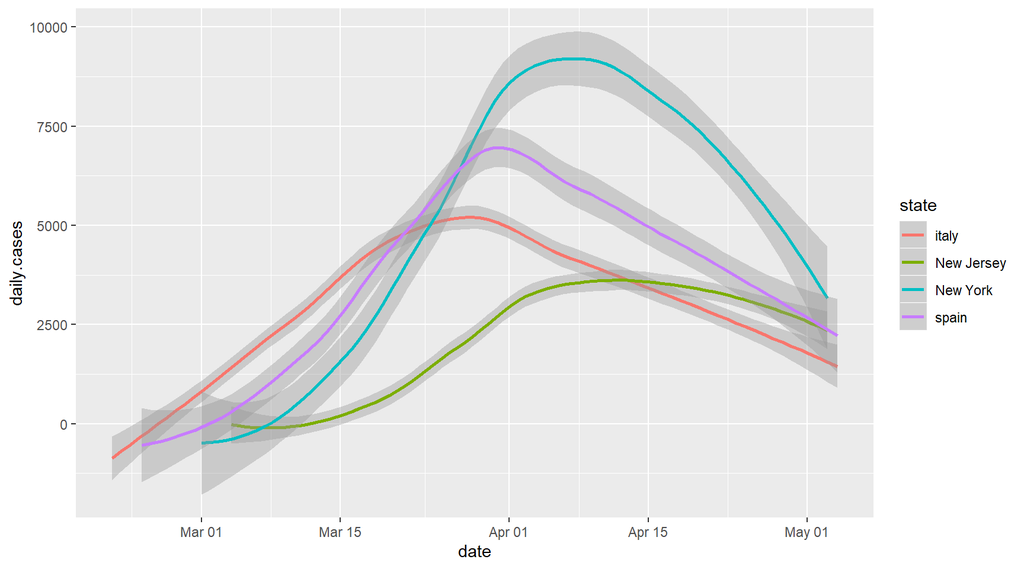

```r
df <- usa_state_data[usa_state_data$state%in%c("New York","New Jersey"),]
df <- bind_rows(df, spain_data %>% mutate(state = "spain"), italy_data %>% mutate(state = "italy"))

ggplot(data = df, mapping = aes(x = date, y = daily.cases, color = state)) + geom_smooth()
```

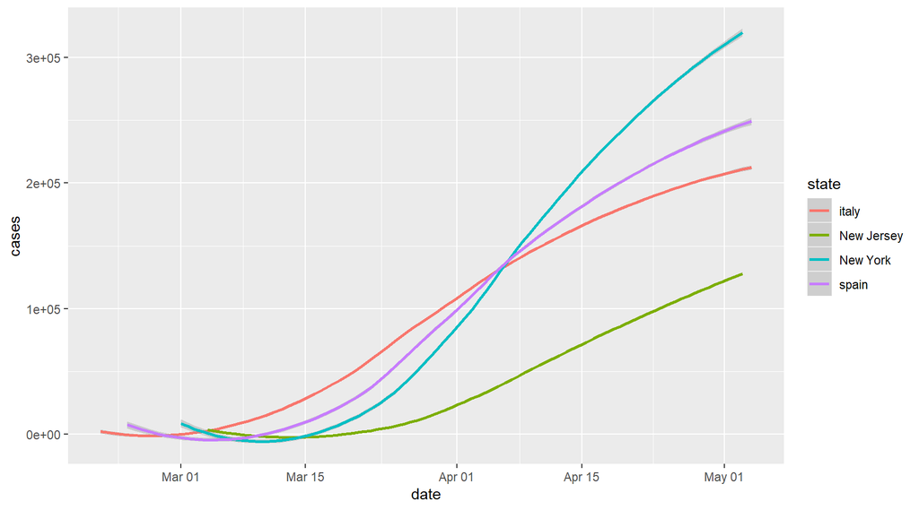

```r
# ggplot(data = df, mapping = aes(x = date, y = daily.deaths, color = state)) + geom_smooth()
ggplot(data = df, mapping = aes(x = date, y = cases, color = state)) + geom_smooth()
```

```r
# ggplot(data = df, mapping = aes(x = date, y = deaths, color = state)) + geom_smooth()
```

Here we can observe a better similarity in trends of number of cases. In all the cases peak has reached and downward trend has started.

I have mentioned in proposal I will predict number of US cases on Spain and Italy data but since then they have drastically changed. So now instead of what I proposed, I will try to fit a polynomial regression to New York data and predict their future values.

I used cross-validation to select the optimal degree for the polynomial

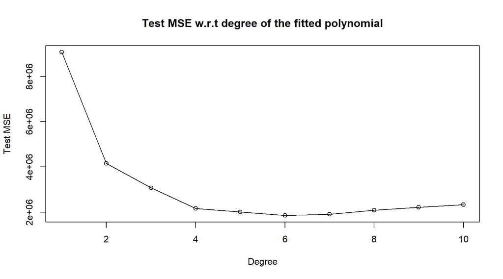

```r
ny_data <- usa_state_data[usa_state_data$state=="New York",]
ny_data$day <- as.numeric(ny_data$date - min(ny_data$date) + 1)

mse <- rep(NA, 10)
for (i in 1:10) {
    fit <- glm(daily.cases ~ poly(day, i), data = ny_data)
    mse[i] <- cv.glm(ny_data, fit, K = 10)$delta[1]
}
plot(1:10, mse, xlab = "Degree", ylab = "Test MSE", type = "o" , main="Test MSE w.r.t degree of the fitted polynomial")
```

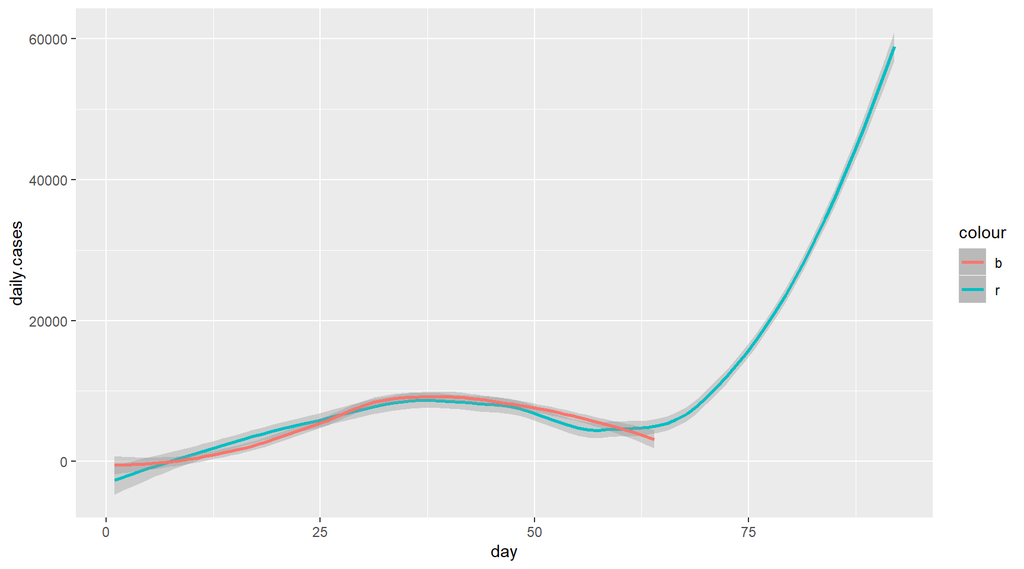

We can clearly see that though a polynomial regression fits well, it doesn’t predict it well(Expecting a downward trend). Let’s build a regression spline and see if it’s predicts better.

I used cross-validation to select the optimal degree for freedom of B-splines.

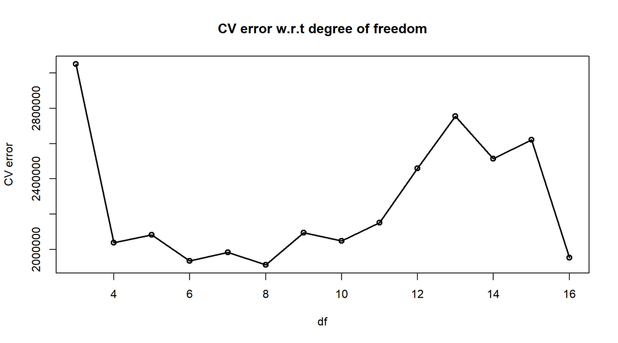

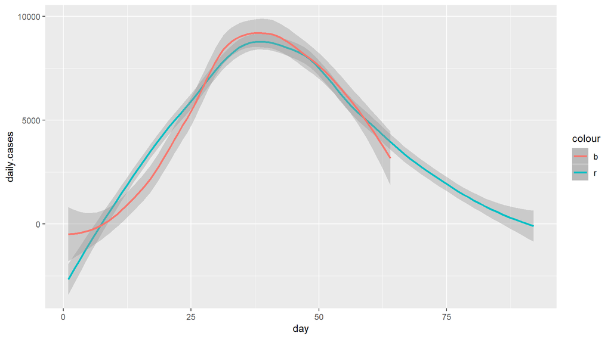

```r
bs.ny <- lm(daily.cases ~ bs(day, knots = c(4, 11, 30, 35, 42)),ny_data)

new.data <- data.frame(day = 1:92)
new.data$daily.cases <- predict(bs.ny, new.data)
ggplot(new.data, mapping = aes(x = day, y = daily.cases, color = "r")) + geom_smooth() +
  geom_smooth(ny_data, mapping = aes(x = day, y = daily.cases, color = "b"))
```

B-spline polynomial spline fits the data well and also predicts it better that the polynomial regression. This is an expected performance.

#### 2) The effect of number of coronavirus cases on the economy by looking at S&P 500 stock market index.

*a)The link https://finance.yahoo.com/quote/%5EGSPC/history?p=%5EGSPC contains daily values of S&P index.*

```r
smindex_data <- read.csv("smiindex.csv",stringsAsFactors = FALSE)
smindex_data$date <- as.Date(smindex_data$date)

sprintf("The highest S&P index rose to is:%.2f and the lowest value it reached is:%.2f", max(smindex_data$High), min(smindex_data$Low))
```

```
## [1] "The highest S&P index rose to is:3393.52 and the lowest value it reached is:2191.86"
```

```r
smindex_data$change <- smindex_data$close - smindex_data$Open
sprintf("The highest gain in S&P index in a day is:%.2f and the highest drop is:%.2f", max(smindex_data$change), abs(min(smindex_data$change)))
```

```
## [1] "The highest gain in S&P index in a day is:141.03 and the highest drop is:150.22"
```

With in a span of a month, from 21-Feb to 21-March, S&P index dropped from 3300 to 2200 points causing a panic. But since then it recovered and now it is around 2800.

*b)Data analysis on US covid19 and S&P 500 data*

```
## 'data.frame':    104 obs. of  7 variables:
##  $ date        : Date, format: "2020-01-21" "2020-01-22" ...
##  $ cases       : int  1 1 1 2 3 5 5 5 5 6 ...
##  $ deaths      : int  0 0 0 0 0 0 0 0 0 0 ...
##  $ daily.cases : num  0 0 0 1 1 2 0 0 0 1 ...
##  $ daily.deaths: num  0 0 0 0 0 0 0 0 0 0 ...
##  $ Open        : num  3321 3330 3316 3333 NA ...
##  $ close       : num  3321 3322 3326 3295 NA ...
```

```
##         date cases deaths daily.cases daily.deaths    Open   close
## 1 2020-01-21     1      0           0            0 3321.03 3320.79
## 2 2020-01-22     1      0           0            0 3330.02 3321.75
## 3 2020-01-23     1      0           0            0 3315.77 3325.54
## 4 2020-01-24     2      0           1            0 3333.10 3295.47
## 5 2020-01-25     3      0           1            0      NA      NA
## 6 2020-01-26     5      0           2            0      NA      NA
```

```
##         date cases deaths daily.cases daily.deaths    Open   close
## 1 2020-01-21     1      0           0            0 3321.03 3320.79
## 2 2020-01-22     1      0           0            0 3330.02 3321.75
## 3 2020-01-23     1      0           0            0 3315.77 3325.54
## 4 2020-01-24     2      0           1            0 3333.10 3295.47
## 5 2020-01-25     3      0           1            0 3333.10 3295.47
## 6 2020-01-26     5      0           2            0 3333.10 3295.47
```

```
##             cases     deaths       Open      close
## cases   1.0000000  0.9896053 -0.2759642 -0.2718773
## deaths  0.9896053  1.0000000 -0.2058848 -0.2046184
## Open   -0.2759642 -0.2058848  1.0000000  0.9849152
## close  -0.2718773 -0.2046184  0.9849152  1.0000000
```

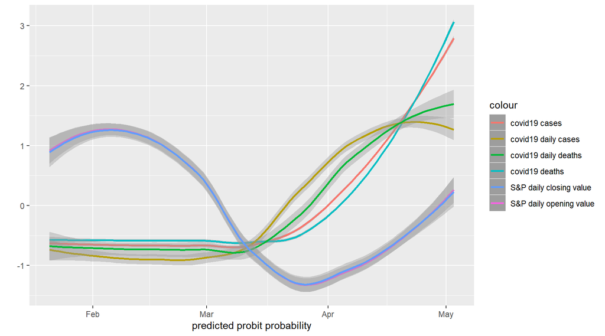

Though these we don’t observe a clear negative trend but we can see that S&P index intially dropped due to rise in covid19 cases but after reaching a low has started to rise. That might due to increased measures taken by govt or other reasons, which might have made the public to reassure about US economy.